# week 1 philosophy code version

# What is interesting about modern philosophy? Specifically, empiricism?

Philosophy, as a discipline that shows people’s love for wisdom, has been exuding vigor and vitality for thousands of years. Philosophers think about different questions from different perspectives and give different answers, and various schools of philosophy are born.

In this work, we will focus on modern philosophy. Here is an outline of questions we will talk about.

Q1: Although in a similar historical period, what are the main considerations of different schools of modern philosophy?

Q2: Are the emotions in their works the same? Comparisons between different schools draw our attention to empiricism. Why?

Q3: All belonging to empiricism, are the emotions in the works of 3 different philosophers the same?

# step 0 - Install and load libraries

# step 1 - Data Processing

```r
d=read_csv("../data/philosophy_data 2.csv")
df=d%>%
  group_by(title,author,school,original_publication_date)%>%
  summarise(sentence_length=sum(sentence_length))%>%
  arrange(school)
dta <- d%>%
  group_by(title,author,school,original_publication_date)%>%
  summarise(length=sum(sentence_length))%>%
  mutate(year=make_date(original_publication_date, 1, 1),length=length/2500000)%>%
  select(species=author,year,length,school,title)
```

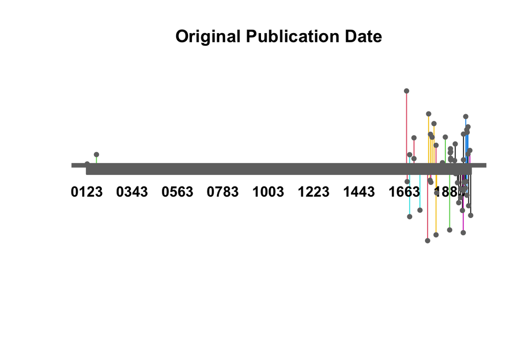

```r
#visualize the original_publication_date. Color represents different school
dta%>%filter(year>as.Date("0/1/1"))%>%
  timelineS(main = "Original Publication Date",scale="year",labels=NULL,
          label.length=.$length,label.color=factor(.$school),label.angle=90)
```

Data Source: History of Philosophy https://www.kaggle.com/kouroshalizadeh/history-of-philosophy Context: Sentences taken from 51 texts spanning the history of philosophy

From the timeline above, it’s easy to tell that this dataset primarily contains texts of philosophy after 1600 AD, which are mainly modern philosophy and contemporary philosophy.

In this work, we will focus on modern philosophy.

```r
school_first_pub<-# arrange school name by the first year of its publication
  dta%>%group_by(school)%>%
  mutate(order=order(year))%>%
  arrange(order,year)%>%
  filter(order==1)%>%
  pull(school)

sel.comparison= school_first_pub[3:13]
#doesn't include "aristotle","plato"(BC)
```

#step 2: Different schools of Philosophy. What were they concerning about?

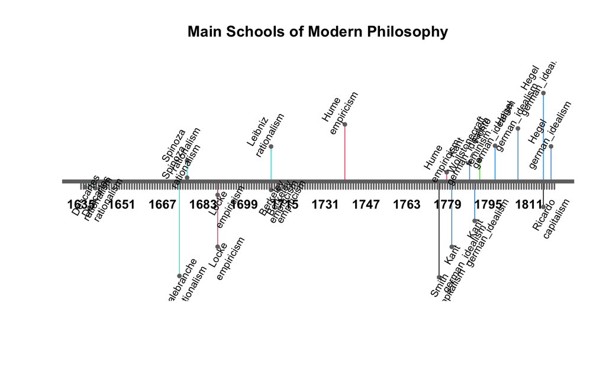

```r
#pull the schools of modern philosophy out
school_sel <-
  dta%>%
  filter(year>as.Date("1400/1/1")&year<as.Date("1840/1/1"))%>%
  group_by(school)%>%# arrange school name by the first year of its publication
  mutate(order=order(year))%>%
  arrange(order,year)%>%
  filter(order==1)%>%
  pull(school)
school_sel<-school_sel[-5] #drop feminism since it was not mainly developed during this period


#modern philosophy
dta%>%filter(year>as.Date("1400/1/1")&year<as.Date("1840/1/1"))%>%
  timelineS(main = "Main Schools of Modern Philosophy",scale="year",
            labels=paste0(.$species,"\n  ",.$school),
          label.length=.$length,label.color=factor(.$school),label.angle=60)
```

```r
# dta%>%filter(school %in% school_sel)%>%
#     timelineS(main = "Main Schools of Modern Philosophy",scale="year",labels=paste0(.$species),
#           label.length=.$length,label.color=factor(.$school),label.angle=60)
#time span is a little bit different from the last one
?paste0
```

The 17th and early 20th centuries roughly mark the beginning and the end of modern philosophy. Here we mainly study 4 schools: rationalism, capitalism, empiricism, and German idealism.

```r
#word cloud of different schools

#unique(df$school)
l<-vector("list",length=length(school_sel))

for(i in 1:length(school_sel)){
  d_school = d%>%filter(school==school_sel[i])

  ff.all<-VCorpus(VectorSource(d_school$sentence_lowered))
  ff.all<-tm_map(ff.all, stripWhitespace)
  ff.all<-tm_map(ff.all, content_transformer(tolower))
  ff.all<-tm_map(ff.all, removeWords, stopwords("english"))
  ff.all<-tm_map(ff.all, removeWords, character(0))
  ff.all<-tm_map(ff.all, removePunctuation)
  stop_words_zx<-c("will","may","must","shall","can","also")
  ff.all<-tm_map(ff.all, removeWords, stop_words_zx)
  ff.all

  tdm.all<-TermDocumentMatrix(ff.all)
  tdm.all

  # Turn the Term Document Matrix into a tidy tibble
  tdm.tidy=tidy(tdm.all)
  #kable(tdm.tidy[1:10,])

  # Get the Overall Counts over the Whole Corpus
  tdm.overall=summarise(group_by(tdm.tidy, term), sum(count))
  #kable(tdm.overall[101:110,])

  l[[i]]<-tdm.overall # store it in a list
}
```

## rationalism

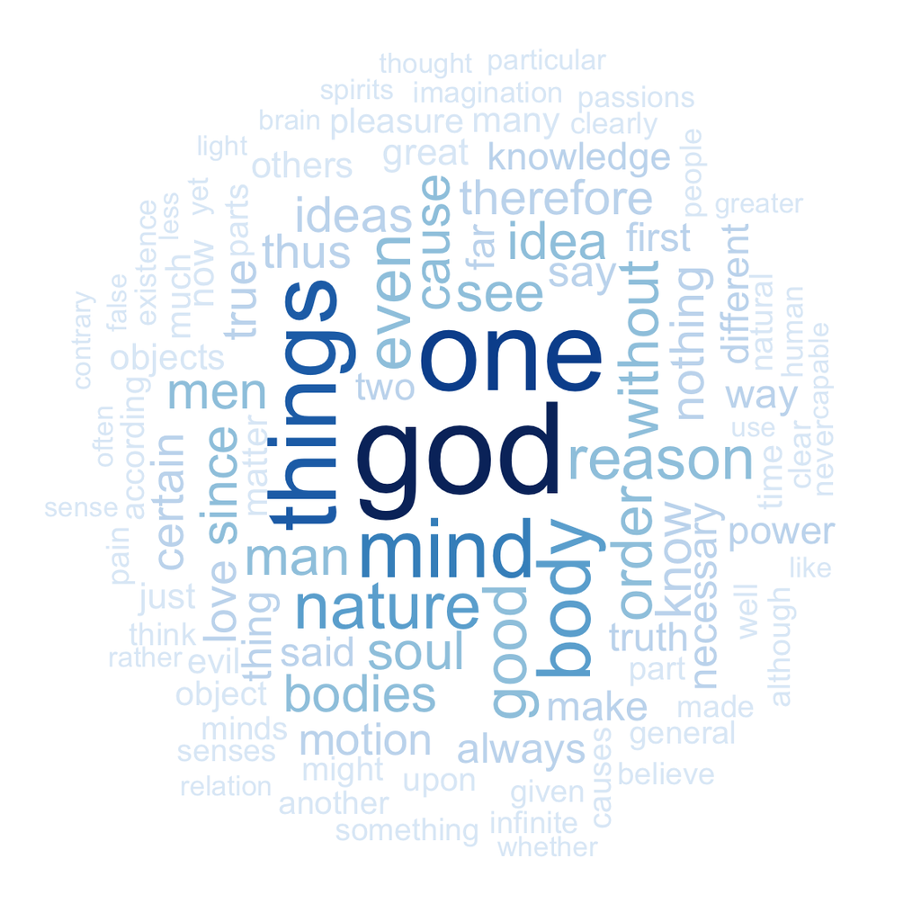

```r
  #word cloud
  wordcloud(l[[1]]$term, l[[1]]$`sum(count)`,
          scale=c(5,0.5),
          max.words=100,
          min.freq=1,
          random.order=FALSE,
          rot.per=0.3,
          random.color=FALSE,
          colors=brewer.pal(9,"Blues"))
```

Why did rationalism philosophers talk a lot about “god”?

Modern philosophy traditionally begins with René Descartes and his dictum “I think, therefore I am”. Descartes finds that some of the ideas he has could not have originated from him alone, but only from God; he proves that God exists. He then demonstrates that God would not allow him to be systematically deceived about everything; in essence, he vindicates ordinary methods of science and reasoning, as fallible but not false.(Reference: https://en.wikipedia.org/wiki/Modern_philosophy)

So “god” was mentioned a lot.

Some sentences including the keyword “god”:

```r
print(d%>%filter(school==school_sel[1])%>%
  dplyr::filter(grepl("god",sentence_lowered))%>%
  select(sentence_lowered)%>%
  sample_n(2)%>%
  unlist())
```

```
##                                                                                                                                                                                                                                                     sentence_lowered1
##                                                                                                                       "by body i mean a mode which expresses in a certain determinate manner the essence of god, in so far as he is considered as an extended thing."
##                                                                                                                                                                                                                                                     sentence_lowered2
## "when god produces the thing he produces it as an individual and not as a universal of logic (i admit); but he produces its essence before its accidents, its nature before its operations, following the priority of their nature, and in signo anteriore rationis."
```

## capitalism

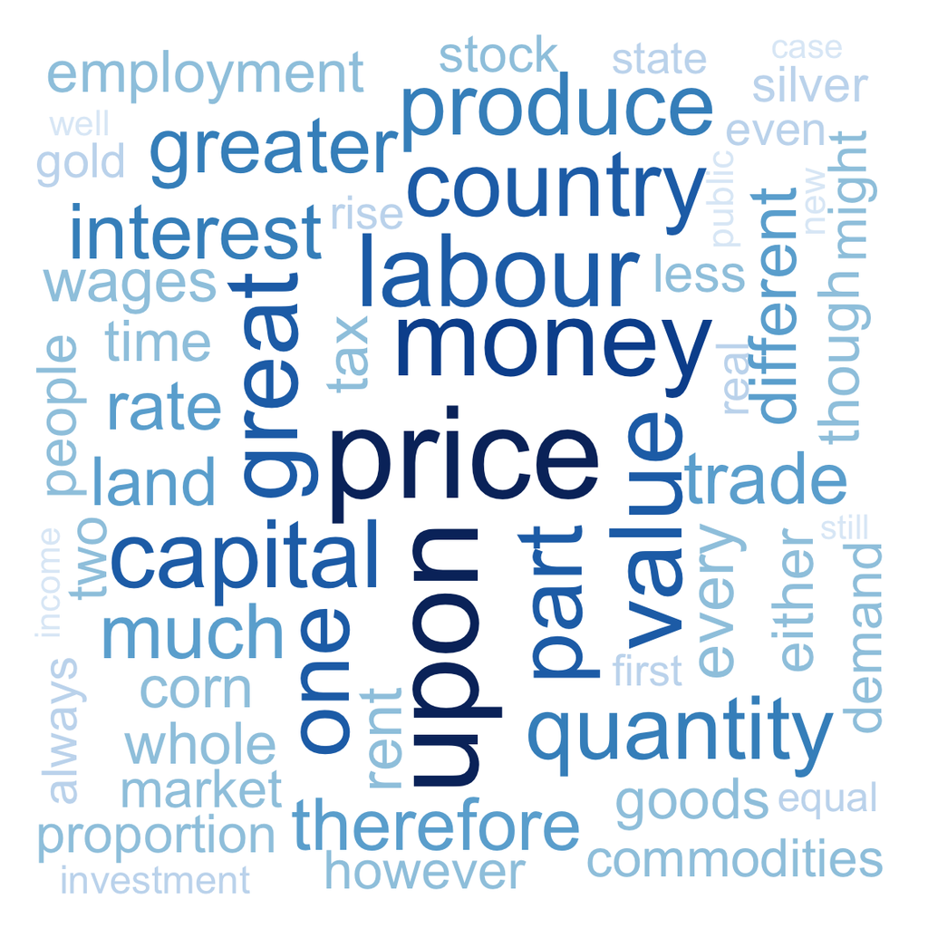

```r
  #word cloud
  wordcloud(l[[2]]$term, l[[2]]$`sum(count)`,
          scale=c(5,0.5),
          max.words=100,
          min.freq=1,
          random.order=FALSE,
          rot.per=0.3,
          random.color=FALSE,
          colors=brewer.pal(9,"Blues"))
```

Capitalism talks a lot about “price”, “money”, “value”, “labour”, “wage”, etc. This is corresponding to its key features – personal ownership of property, open competition, and individual incentives. (Reference: https://www.investopedia.com/ask/answers/042215/what-difference-between-capitalist-system-and-free-market-system.asp)

```r
print(d%>%filter(school==school_sel[2])%>%
  dplyr::filter(grepl("price",sentence_lowered))%>%
  select(sentence_lowered)%>%
  sample_n(2)%>%
  unlist())
```

```
##                                                                                                                                                                                                              sentence_lowered1
##                                                                 "of the wealth of nations, mr. buchanan observes, but the price of corn does not regulate the money price of all the other parts of the rude produce of land."
##                                                                                                                                                                                                              sentence_lowered2
## "according to the degree in which it bears on manufacturing and agricultural profits equally, it will be a general tax on the profits of stock, and will occasion no alteration in the price of raw produce and manufactures."
```

## empiricism

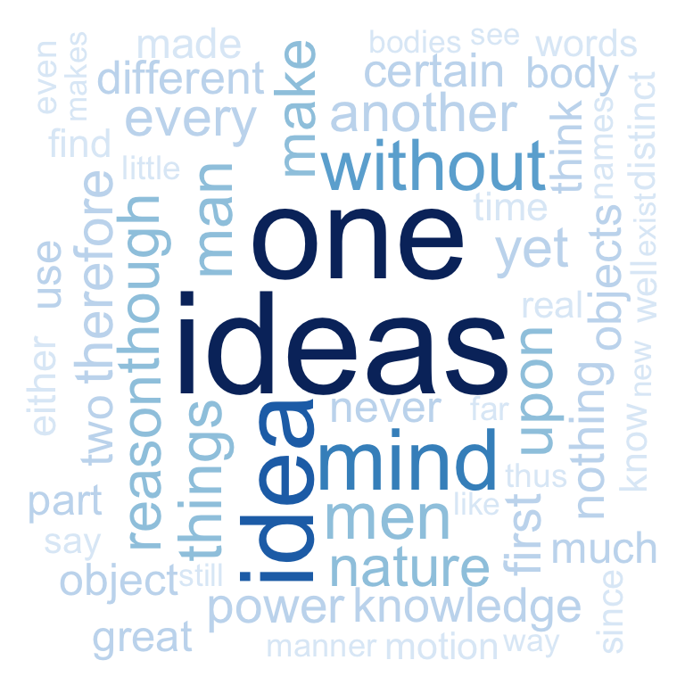

```r
  #word cloud
  wordcloud(l[[3]]$term, l[[3]]$`sum(count)`,
          scale=c(5,0.5),
          max.words=100,
          min.freq=1,
          random.order=FALSE,
          rot.per=0.3,
          random.color=FALSE,
          colors=brewer.pal(9,"Blues"))
```

“Ideas”: The word cloud helps us get an intuition that “ideas” is an important topic of empiricism. In fact, one thing empiricists cares about is the formation of ideas. Empiricism emphasizes the role of empirical evidence in the formation of ideas, rather than innate ideas or traditions. (Reference: https://en.wikipedia.org/wiki/Empiricism)

Some sentences:

```r
print(d%>%filter(school==school_sel[3])%>%
  dplyr::filter(grepl("ideas",sentence_lowered))%>%
  select(sentence_lowered)%>%
  sample_n(2)%>%
  unlist())
```

[output not shown]

## german idealism

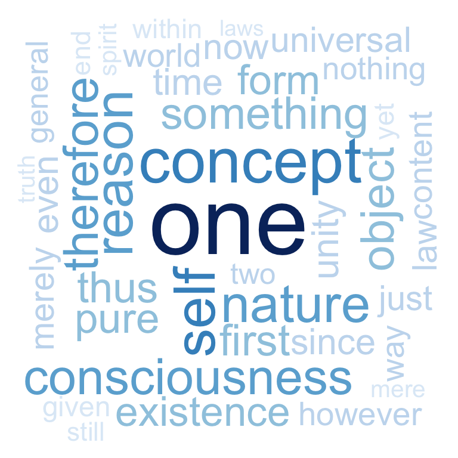

```r
  #word cloud
  wordcloud(l[[4]]$term, l[[4]]$`sum(count)`,
          scale=c(5,0.5),
          max.words=100,
          min.freq=1,
          random.order=FALSE,
          rot.per=0.3,
          random.color=FALSE,
          colors=brewer.pal(9,"Blues"))
```

“one”, “self”, “consciousness”, nature”

Idealism asserts that reality is akin to ideas, thought, mind, or selves rather than to material forces. Idealism is a way of interpreting human experience and the world which places emphasis on mind as in some way prior to matter. Just as materialism emphasizes matter, so idealism stresses mind. (Reference: http://www.uop.edu.pk/ocontents/IDEALISM%20and%20ITS%20TYPES.pdf)

Some sentences:

```r
print(d%>%filter(school==school_sel[4])%>%
  dplyr::filter(grepl("one",sentence_lowered))%>%
  select(sentence_lowered)%>%
  sample_n(2)%>%
  unlist())
```

[output not shown]

# Step 3: Are the emotions in their works the same? Seems like “empiricism” has more “disgust”.

```r
# d%>%
#   filter(school %in% school_sel)%>%
#   group_by(school)%>%
#   count() # how many sentences for each school in this database
set.seed(500)
sentence.list=NULL

school.speech.list=# group by school,only study schools we are interested in
    d%>%
  filter(school %in% school_sel)%>%
  group_by(school)%>%
  summarise(fulltext=paste(sentence_spacy,collapse = ''))


for(i in 1:nrow(school.speech.list)){
  sentences=syuzhet::get_sentences(school.speech.list$fulltext[i])
  if(length(sentences)>0){
    emotions=matrix(emotion(sentences)$emotion,
                    nrow=length(sentences),
                    byrow=T)
    colnames(emotions)=emotion(sentences[1])$emotion_type
    emotions=data.frame(emotions)
    emotions=select(emotions,
                   anticipation,
                   joy,
                   surprise,
                   trust,
                   anger,
                   disgust,
                   fear,
                   sadness)
    word.count=f.word_count(sentences)
    # colnames(emotions)=paste0("emo.", colnames(emotions))
    # in case the word counts are zeros?
    # emotions=diag(1/(word.count+0.01))%*%as.matrix(emotions)
    sentence.list=rbind(sentence.list,
                        cbind(school.speech.list[i,-ncol(school.speech.list)],
                              sentences=as.character(sentences),
                              word.count,
                              emotions,
                              sent.id=1:length(sentences)
                              )
    )
  }
}

#save(sentence.list,file="sentence.list.Rdata")
#names(sentence.list)
```

```r
sentence.list=
  sentence.list%>%
  filter(!is.na(word.count))
```

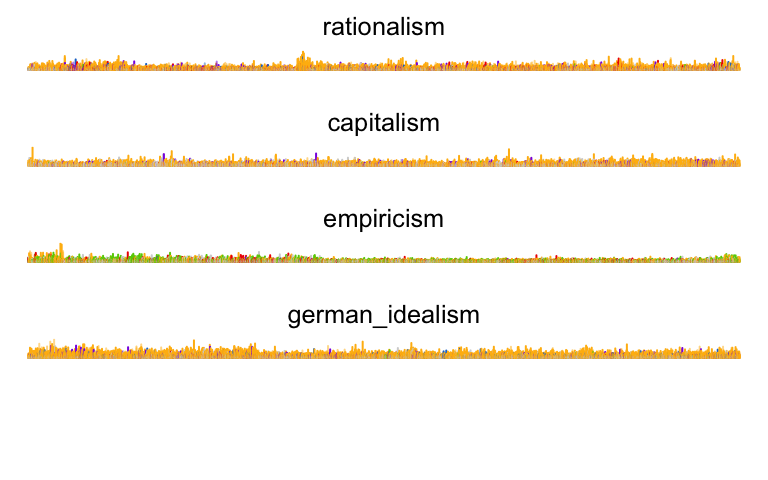

```r
par(mfrow=c(5,1), mar=c(1,0,2,0), bty="n", xaxt="n", yaxt="n", font.main=1)

for(InFile in school_sel){
  f.plotsent.len.school(In.list=sentence.list, InFile=InFile)
}

#nrow(sentence.list%>%filter(school=="rationalism"))
```

From the sentiment analysis, we surprisingly found that compared to the other 3 philosophies, it has more “disgust” emotion. On the contrary, it has less positive emotions such as “anticipation”, “joy”, “surprise”, and “joy”.

### What are the emotionally charged sentences?

```r
emotions.types=c("anticipation", "joy", "surprise", "trust",
                 "anger", "disgust", "fear", "sadness")
i=1

emo_charged_sen<-vector("list",length(school_sel))

for(i in 1:length(school_sel)){
  speech.df=tibble::as_tibble(sentence.list)%>%
     filter(school==school_sel[i], word.count>=4)%>%
  select(sentences, anticipation:sadness)
  speech.df=tibble::as_tibble(speech.df)
  emo_charged_sen[[i]]<-as.character(speech.df$sentences[apply(speech.df[,-1], 2, which.max)])
}

# for(i in 1:length(school_sel)){
#   print(school_sel[i])
#   print(emo_charged_sen[[i]])
#
# }
```

rationalism

```r
#school_sel[1]
emo_charged_sen[[1]]
```

```
## [1] "That only God is our good."
## [2] "That only God is our good."
## [3] "weight with very rapid vibrations that animate."
## [4] "The general rule God follows in this."
## [5] "Metaphysical evil consists in mere imperfection, physical evil in suffering, and moral evil in sin."
## [6] "Metaphysical evil consists in mere imperfection, physical evil in suffering, and moral evil in sin."
## [7] "For fear is pain (Def."
## [8] "Metaphysical evil consists in mere imperfection, physical evil in suffering, and moral evil in sin."
```

capitalism

```r
#school_sel[2]
emo_charged_sen[[2]]
```

```
## [1] "Italy seems not to have gone backwards."
## [2] "below its standard weight."
## [3] "Net money produce No."
## [4] "ths of our present money."
## [5] "Net money produce No."
## [6] "This was not accidental."
## [7] "This odious visit rendered the tax odious."
## [8] "Net money produce No."
```

empiricism

```r
#school_sel[3]
emo_charged_sen[[3]]
```

```
## [1] "I cannot contradict you."
## [2] "Spurns the dank soil in winged flight."
## [3] "It is senseless without doubt."
## [4] "Without doubt it cannot."
## [5] "Moral Good and Evil."
## [6] "Spirits capable of Motion."
## [7] "Nor Duration by Motion."
## [8] "But any great Uneasiness is never neglected."
```

german_idealism

```r
#school_sel[4]
emo_charged_sen[[4]]
```

```
## [1] "owing in theformofshapes.ofcqnsciougness."
## [2] "Of the highest good: Bestandst ck.I.e., of the highest good."
## [3] "Of the highest good: Bestandst ck.I.e., of the highest good."
## [4] "The ground has a determinate content."
## [5] "There is no difficulty in answering."
## [6] "owing in theformofshapes.ofcqnsciougness."
## [7] "owing in theformofshapes.ofcqnsciougness."
## [8] "die Art, aufweiche Weise."
```

```r
#Multiple strongest emotions in the same sentence
```

# Step 4: Pay attention to empiricism, are the emotions in the works of 3 different philosophers the same? Whose work contributes more to the “disgust” emotion?

[figure not shown]

```r
# heatmap.2(cor(sentence.list%>%select(anticipation:sadness)
#               ),
#           scale = "none",
#           col = bluered(100), , margin=c(6, 6), key=F,
#           trace = "none", density.info = "none")

par(mar=c(4, 6, 2, 1))
emo.means=colMeans(select(sentence.list%>%filter(school=="empiricism"), anticipation:sadness)>0.01)
col.use=c("darkgoldenrod1", "darkgoldenrod1", "darkgoldenrod1", "darkgoldenrod1",
            "red2", "chartreuse3", "blueviolet","dodgerblue3")
barplot(emo.means[order(emo.means)], las=2, col=col.use[order(emo.means)], horiz=T, main="empiricism")
```

This result matches our intuition gotten from the above picture – “disgust” is a major emotion in empiricism’ s works. Besides, “surprise”, “anger”, “joy” also important. So it’s look into different authors’ works.

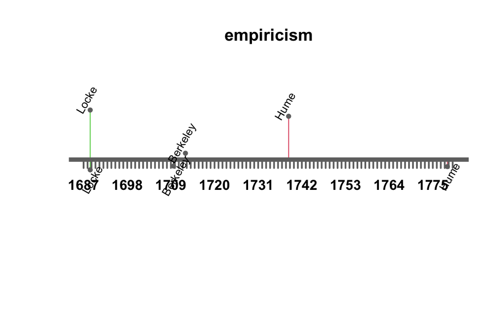

```r
dta%>%filter(school=="empiricism")%>%
    timelineS(main = "empiricism",scale="year",labels=.$species,
          label.length=.$length,label.color=factor(.$species),label.angle=60)
```

```r
#different author

author.sentence.list=NULL


author.speech.list= # group by school,author,title,only study schools we are interested in
  d%>%
  filter(school=="empiricism")%>%
  group_by(school,author)%>%
  summarise(fulltext=paste(sentence_spacy,collapse = ''))
i=1
for(i in 1:nrow(author.speech.list)){
  sentences=syuzhet::get_sentences(author.speech.list$fulltext[i])
  if(length(sentences)>0){
    emotions=matrix(emotion(sentences)$emotion,
                    nrow=length(sentences),
                    byrow=T)
    colnames(emotions)=emotion(sentences[1])$emotion_type
    emotions=data.frame(emotions)
    emotions=select(emotions,
                   anticipation,
                   joy,
                   surprise,
                   trust,
                   anger,
                   disgust,
                   fear,
                   sadness)
    word.count=f.word_count(sentences)
    # colnames(emotions)=paste0("emo.", colnames(emotions))
    # in case the word counts are zeros?
    # emotions=diag(1/(word.count+0.01))%*%as.matrix(emotions)
    author.sentence.list=rbind(author.sentence.list,
                        cbind(author.speech.list[i,-ncol(author.speech.list)],
                              sentences=as.character(sentences),
                              word.count=word.count,
                              emotions,
                              sent.id=1:length(sentences)
                              )
    )
  }
}

names(author.sentence.list)
```

```
##  [1] "school"       "author"       "sentences"    "word.count"   "anticipation"
##  [6] "joy"          "surprise"     "trust"        "anger"        "disgust"
## [11] "fear"         "sadness"      "sent.id"
```

```r
author.sentence.list=
  author.sentence.list%>%
  filter(!is.na(word.count))

author.sentence.list%>%pull(author)%>%unique()
```

```
## [1] "Berkeley" "Hume"     "Locke"
```

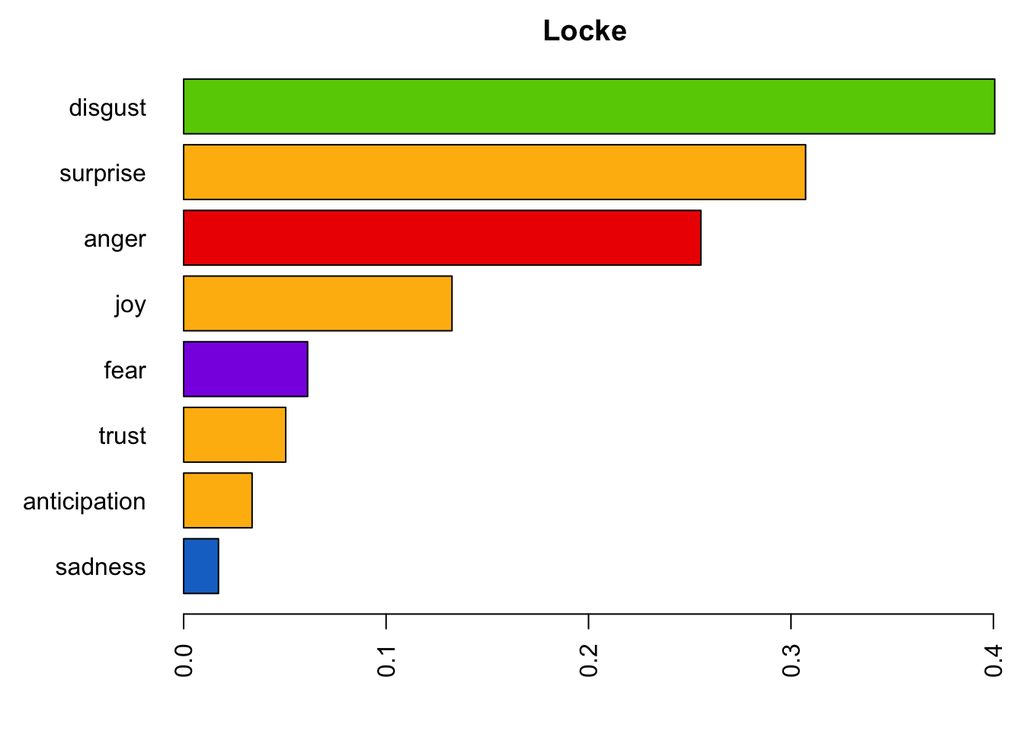

```r
par(mar=c(4, 6, 2, 1))
emo.means=colMeans(select(author.sentence.list%>%ungroup()%>%filter(author=="Locke" ), anticipation:sadness)>0.01)
col.use=c("darkgoldenrod1", "darkgoldenrod1", "darkgoldenrod1", "darkgoldenrod1",
            "red2", "chartreuse3", "blueviolet","dodgerblue3")
barplot(emo.means[order(emo.means)], las=2, col=col.use[order(emo.means)], horiz=T, main= "Locke")
```

### What are the emotionally charged sentences?

```r
emotions.types=c("anticipation", "joy", "surprise", "trust",
                 "anger", "disgust", "fear", "sadness")

tibble::as_tibble(author.sentence.list)%>%
     filter(author=="Locke", word.count>=4)%>%
    select(sentences, disgust)%>%
    dplyr::arrange(desc(disgust))%>%
    select(sentences)%>%
    head(n=6)%>%
  unlist()
```

```
##                                                 sentences1
##                               "Spirits capable of Motion."
##                                                 sentences2
## "Absent good unable to counterbalance present uneasiness."
##                                                 sentences3
##                     "Because Uneasiness alone is present."
##                                                 sentences4
##   "An Inquiry into the Understanding pleasant and useful."
##                                                 sentences5
##                                  "Motion proves a Vacuum."
##                                                 sentences6
##                                  "Simple modes of motion."
```

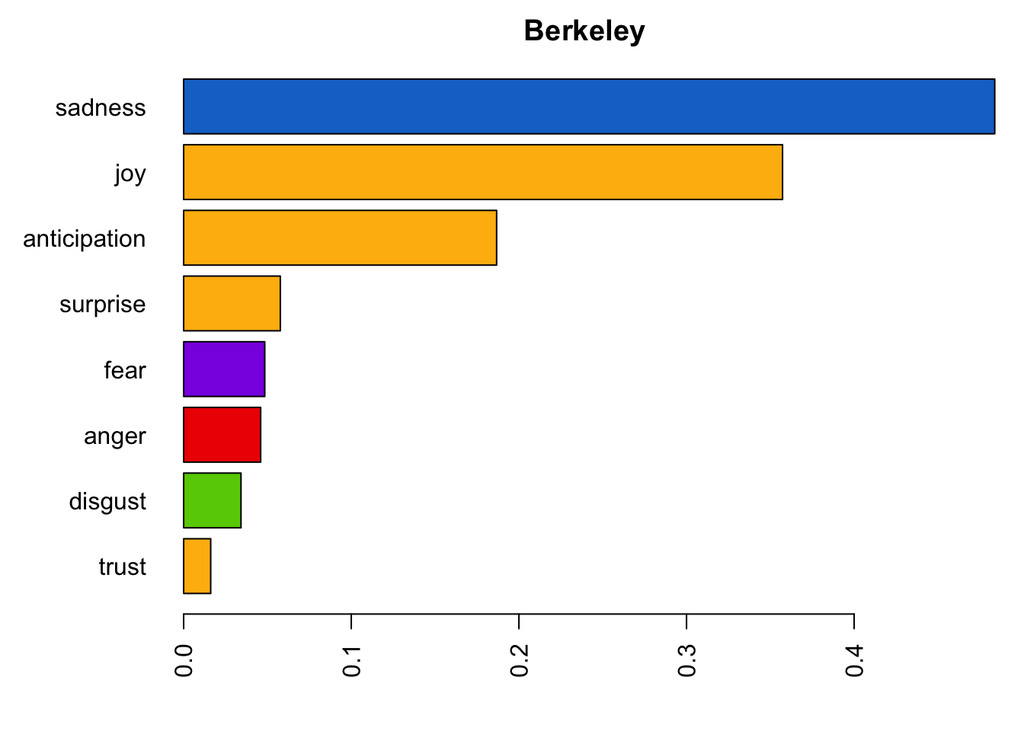

```r
par(mar=c(4, 6, 2, 1))
emo.means=colMeans(select(author.sentence.list%>%ungroup()%>%filter(author=="Berkeley"), anticipation:sadness)>0.01)
col.use=c("darkgoldenrod1", "darkgoldenrod1", "darkgoldenrod1", "darkgoldenrod1",
            "red2", "chartreuse3", "blueviolet","dodgerblue3")
barplot(emo.means[order(emo.means)], las=2, col=col.use[order(emo.means)], horiz=T, main= "Berkeley")
```

```r
emotions.types=c("anticipation", "joy", "surprise", "trust",
                 "anger", "disgust", "fear", "sadness")

tibble::as_tibble(author.sentence.list)%>%
     filter(author=="Berkeley", word.count>=4)%>%
    dplyr::arrange(desc(sadness))%>%
    select(sentences)%>%
    head(n=6)%>%
  unlist()
```

```
##                                                               sentences1
##                                            "By a microscope, doubtless."
##                                                               sentences2
##                          "Pray how do the mathematicians treat of them?"
##                                                               sentences3
##                                          "A little patience, Philonous."
##                                                               sentences4
## "If immediately, pray inform me by which of the senses you perceive it."
##                                                               sentences5
##                       "And have true and real colours inhering in them?"
##                                                               sentences6
##                                         "It is senseless without doubt."
```

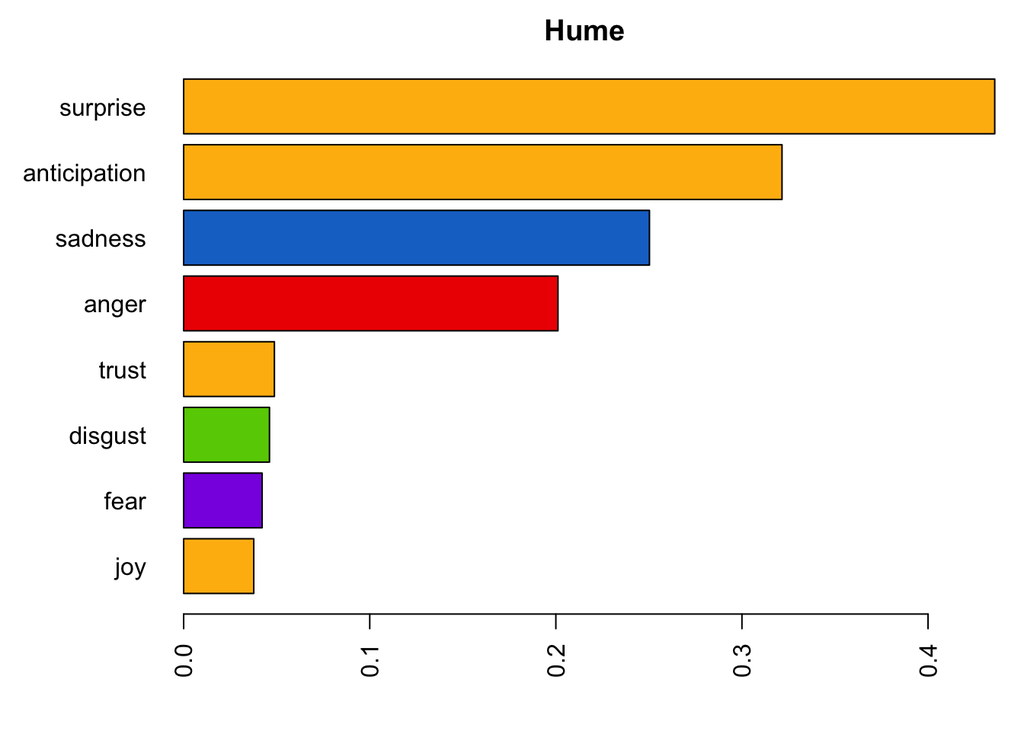

```r
par(mar=c(4, 6, 2, 1))
emo.means=colMeans(select(author.sentence.list%>%ungroup()%>%filter(author=="Hume"), anticipation:sadness)>0.01)
col.use=c("darkgoldenrod1", "darkgoldenrod1", "darkgoldenrod1", "darkgoldenrod1",
            "red2", "chartreuse3", "blueviolet","dodgerblue3")
barplot(emo.means[order(emo.means)], las=2, col=col.use[order(emo.means)], horiz=T, main= "Hume")
```

```r
emotions.types=c("anticipation", "joy", "surprise", "trust",
                 "anger", "disgust", "fear", "sadness")

tibble::as_tibble(author.sentence.list)%>%
     filter(author=="Hume", word.count>=4)%>%
    dplyr::arrange(desc(surprise))%>%
    select(sentences)%>%
    head(n=6)%>%
  unlist()
```

```
##                                                sentences1
##          "Good princes enjoy sound health and long life."
##                                                sentences2
##             "Ourself is always intimately present to us."
##                                                sentences3
##                    "But pain often, good God, how often!"
##                                                sentences4
##  "To every probability there is an opposite possibility."
##                                                sentences5
##                                "What beings surround me?"
##                                                sentences6
## "Morals excite passions, and produce or prevent actions."
```

Compare the results of three different philosophers – Locke, Berkeley and Hume. Locke’s work contributes the most to “disgust”.

Surprisingly, the leading emotions of these 3 philosophers are totally different, although they all belong to empiricism. The major emotion of Locke’s ideas is “disgust”, of Berkeley’s is “sad”, and of Hume’s is surprise.

#Conclusion In this assignment, we primarily focus on 4 modern philosophy schools –rationalism, capitalism, empirilism, and german idealism. Word cloud helps us identify the key features of each school. Using sentiment analysis, we find compared to the other three schools, empiricism has more “disgust” emotion. Diving into it, this is mainly because of Locke’s works. In addition, although all belongs to empiricism, Berkeley’s work is m “sadder”, and Hume’s work has more “surprise”.